# Mid-Semester Course Evaluation Results

| **Course** | Advanced Database Systems |
| --- | --- |
| **Course Code** | BBT3104 |
| **Class** | BBIT 2.2 |
| **Semester Duration** | 19<sup>th</sup> August 2024 to 25<sup>th</sup> November 2024 |
| **Date of Evaluation** | 23<sup>rd</sup> September 2024 to 29<sup>th</sup> September 2024 (Week 6 of 14) |
| **Total number of students who submitted the course evaluation** | 171 |
| **Total number of students registered in the AMS at the time of the course evaluation** | 192 |
| **Response rate** | 89% |
| **e-Learning URL** | https://classroom.google.com/c/NzAxMDA1ODc3MzU4?cjc=cqyoyyy |
| **Data collection tool** | https://docs.google.com/forms/d/e/1FAIpQLSd4By-juKjo3nB_ZEFWEdpUpWKBsTPeibqkYcoBKwZ0BOgXRg/viewform?usp=sf_link |
| **Raw Data** | https://docs.google.com/spreadsheets/d/1R7UcA0w7yNBO1e0FeC2SusxJt9u3GsVkC5mOZQ-bP4k/edit?usp=sharing |
| **Lecturer** | Dr Allan Omondi <aomondi@strathmore.edu> |

# Course Evaluation Score

Mean Course Evaluation Score = 4.3769 / 5

Percentage Mean Course Evaluation Score = 87.54%

Median Course Evaluation Score = 4.4545 / 5

# Quantitative Data Analysis

## Course Evaluation Scores per Group

The **“Average Course Evaluation Rating”** variable in the plot below indicates the score **per gender** with a baseline of 4/5.

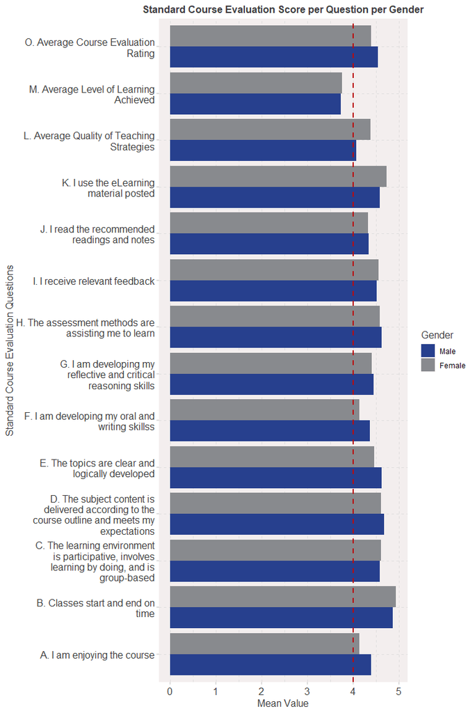

The **“Average Course Evaluation Rating”** variable in the plot below indicates the score **per class group** with a baseline of 4/5.

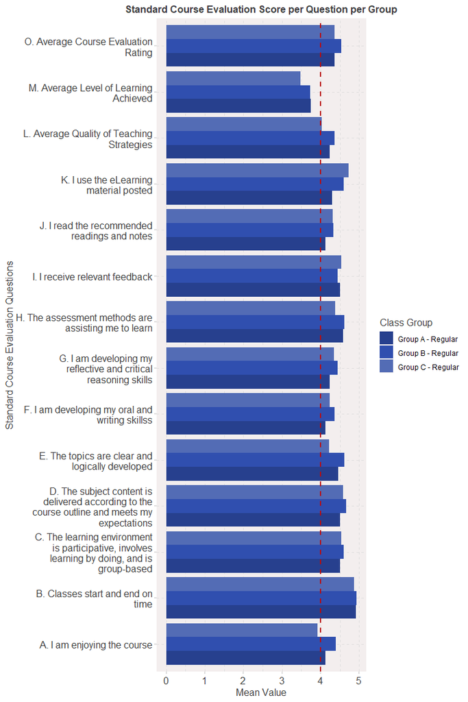

## Correlations

The specific correlation values are presented below:

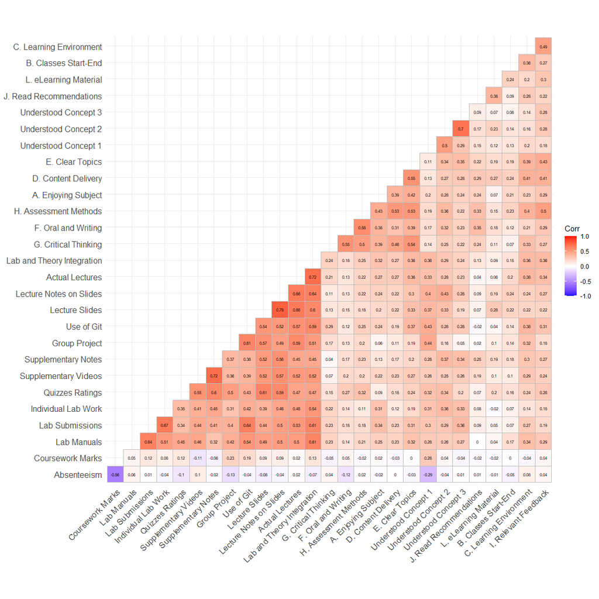

### Interesting Correlations

Correlations worth noting include:

- **0.78 correlation** between “lectures slides” and “lecture notes on some of the lecture slides”: *Having lecture notes to accompany some lecture slides improves the overall quality of the lecture slide*
- **0.72 correlation** between “Supplementary videos to watch as an additional explanation of a topic” and “Supplementary content to read”: *Students who find the supplementary videos useful with regad to their learning also find the supplementary notes useful*
- **0.72 correlation** between “the quality of the lectures given (quality measured by the breadth (the full span of knowledge of a subject) and depth (the extent to which specific topics are focused upon, amplified, and explored) of learning - NOT quality measured by how fun, comical, or entertaining the lectures are)” and “the integration of practical labs in most classes even if it is not in a computer lab”: *Mixing practicals with theory in the same class improves the overall quality of the lecture.*
- **0.7 correlation** between “understood Concept 2 (Conceptual Data Modelling)” and “understood Concept 3 (Database Constraints)”: *Students who do not understand Concept 2 also do not understand Concept 3. It is necessary to understand Concept 2 before moving on to Concept 3.*
- **-0.56 correlation** between “Absenteeism” and “Coursework Marks”: *The higher the absenteeism, the lower the student’s coursework marks*
- **-0.29 correlation** between “Absenteeism” and “Understood Concept 1”: *The more late students are to register for the course, the harder it is for them to understand concept 1*

The negative correlation between “absenteeism” and “coursework marks” is stronger among the female students, i.e., the more classes a student misses, the worse their performance, especially for female students.

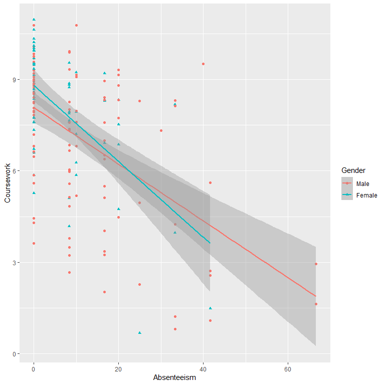

### Absenteeism Percentage

#### Absenteeism by Specific Class Group

Group C has the lowest absenteeism issues despite having a class on Friday afternoon.

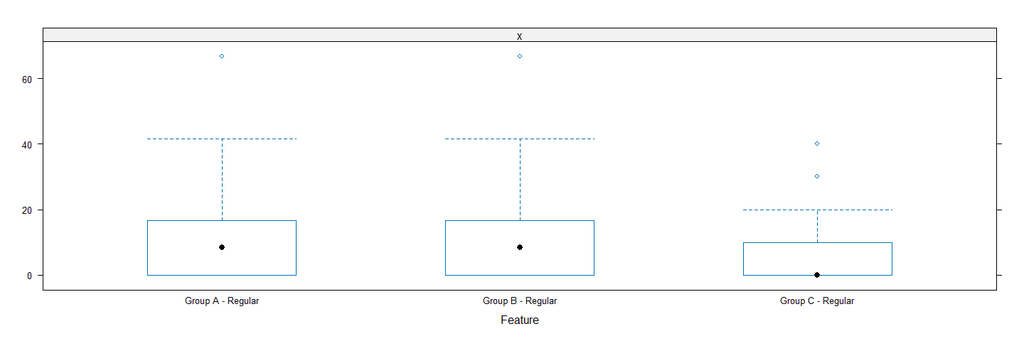

#### Absenteeism by Gender

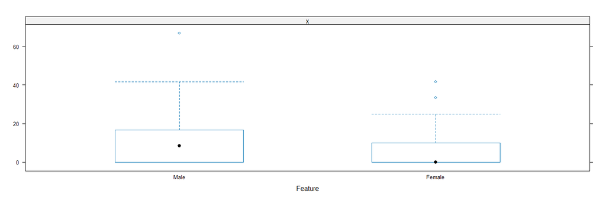

# Qualitative Data Analysis

## Sentiment Analysis (Lexicon-Based)

### Chord Diagram of Sentiments for Likes per Class Group

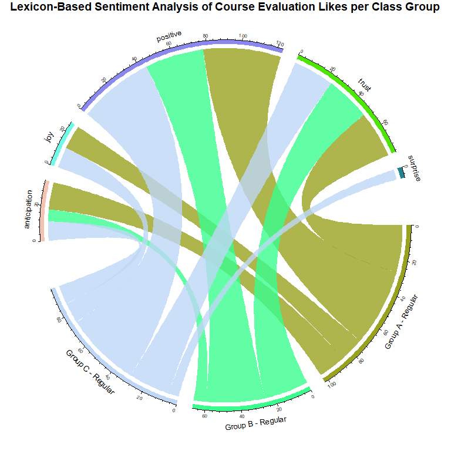

### Chord Diagram of Sentiments for Likes per Class Gender

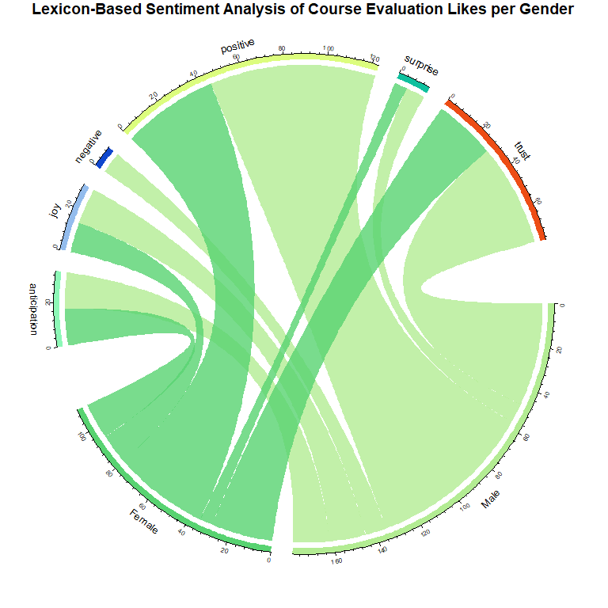

The results are similar for both genders but the male students are more positive and trustworthy based on their choice of words for the “likes question”.

### Chord Diagram of Sentiments for Wishes per Class Group

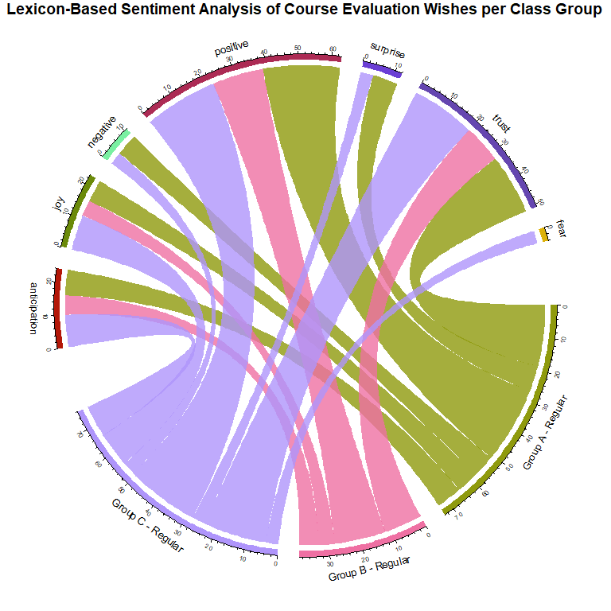

Group A and C express more negative sentiments with Group C also expressing fear based on their choice of words for the “wishes question”.

### Chord Diagram of Sentiments for Wishes per Gender

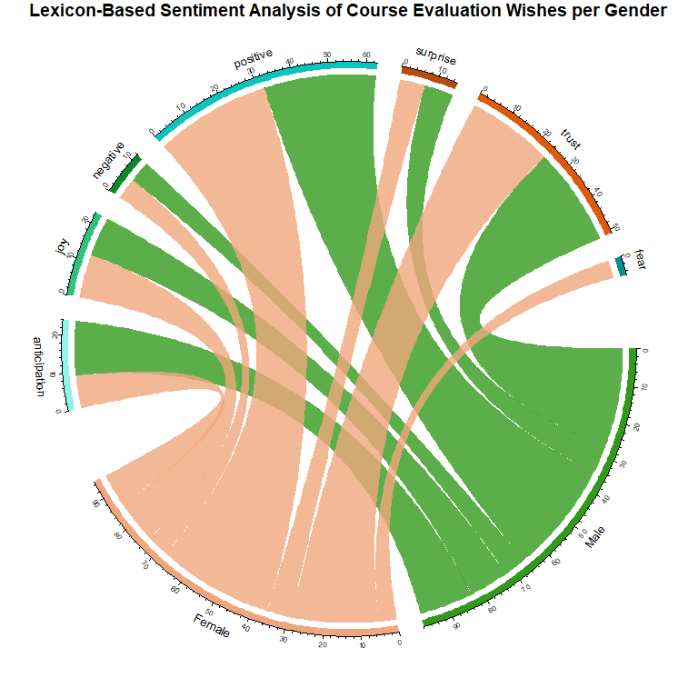

The sentiments for wishes are similar across both genders but female students express more fear than male students based on their choice of words.

## Topic Modelling (Latent Dirichlet Allocation (LDA) based)

The goal of topic modelling is to identify latent (hidden) terms (topics) in the students’ course evaluation textual feedback. In this case, a topic is a mixture of words and a student’s textual feedback is a combination of one or more topics (mixed-membership model).

1. Topic 1: Well-Explained Lectures
2. Topic 2: Collaborative Environment
3. Topic 3: Well-Taught for Ease of Understanding

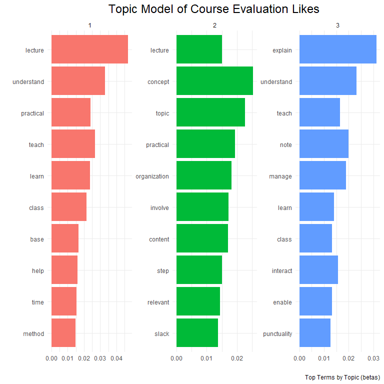

1. Topic 1: Reduce the Workload
2. Topic 2: Reduce the Complexity of the Labs
3. Topic 3: Application of Data Engineering
4. Topic 4: Application of Python

[figure not shown]

# Appendices

## Appendix B: Raw Qualitative Data

### Likes

The raw data of the likes is as follows:

Write two things you like about the teaching and learning in this unit so far

Comment (Likes)

Class punctuality Community feedback on Slack

I love that we have labs that enable me to engage with the content and get some experience of what I would be needed to do in the work environment.

N/A

The content delivery is well done

I like the learning pace and the content with the labs is executable

The topics Labs and group work

The delivery The content

The quizzes, how we learned to use new software i.e. Slack

Inclusive learning relevant feedback is given

Coding in vs and applying it in GitHub

None

n/a

Null

I like how we are given a quiz after each concept in this unit. In this unit, I also like the way we already have all the content online for the whole semester.

The learning is very enjoyable and interesting

I like the concept of doing the short quizzes on google classroom

Triggers and also capabilities and constraints

Lessons are interesting and push us to get more knowledge and to do better

It is Fun. It is interactive

1. I enjoy how organized the results are so I am able to track my performance from the start to the finish
2. I like how detailed the lab manuals are because I am able to fully understand what is happening

its interesting. its relevant

I like that it is much more practical as performing activities is much more beneficial that just sitting an having the information exposited, I also like that the steps for the practicals are detailed and give explanations on their functions

I like that the lecturer gives feedback regarding the projects and labs and that the classes start on time

The lecturer has great delivery method and tries to be at per with his class The lecturer takes his work seriously and gives his students clear expectations

The class is quite interactive and teamwork is also shown in class

the quizes given the way the content is delivered

I like how informative the unit is. I like how there is time allocated to work with my peers, it allows me to understand the concepts more.

The lecturer explains things well,the lec goes with a good pace

configuration of a database transaction event scheduling

Its interactive

interactiveness and time keeping

Assistance when someone has issues during labworks The step by step procedures to do the labs

Broading my knowledge and unnderstanding

1.The quizzes 2.The project

The timely response on slack The quizzes after each concept

The delivery of the content,the lecturer’s commitment on assisting a peson individually

the topics are taught well , One is guided and what and how they are supposed to do the exercises

OK

1. The lecturer takes his time to explain concepts

The lab manuals are well laid out

The quiz The project

topic one and two

The group work makes it fun and engaging The lecturer manages time well, classes end in good time

The group project The way everything is organized

Its good that you keep pushing us …. Thats what amazes me in this unit

Content delivery Quizes

It is very organized, the assignments, labs and group work The concepts are understandable

Explaining being explained in steps by the lecturer.

Learning new things. We do most of the work ourselves so we learn while practicing

Lecturer explains everything to the tea

.

The lecturer is always punctual The learning is efficient

Lecturer

Fun

1. I like it 2.Good lectures

It is very interactive and fun I get to learn new skills based on different perspectives

1.Very well explained 2.Interesting

It is very practical Feedback is relevant and on time

The practicals The teamwork

the detailed explained slides and the time taken to make sure everyone understands

The unit is really involving which is good The unit is interesting

The clear outline of the work The practical examples

The applicability of the unit in modern world

I like the labs and quizzes which check on our progress

I like how the lecturer explains the concepts clearly and logically I like the fact that the lec is always ready to explain unclear and ambiguous concepts

Well Organised, Interactive

The lecturer and what is being taught

Use of real world examples. And Use of structured design and logical thinking

Learning new skills Learning problem solving

Practice is very important for the long run, Database is very broad

The explanation is simple and easy for me to understand. The class is involving by asking questions

it is mostly practical

the lab exercises are engaging if one is committed to them. the extensive use of the GitHub repositories and the other database tools are equipping with practical database experiences

Simple

i.) Classes start and end on time ii.) Lab practiclals are interractive and are fun to do

The topics are well explained and to one’s understanding and learning the topics are interesting as compared to labs

I like the clarity that is offered and the avaliability of the lecturer

He is very organised He is patient when it comes to explaining

simplified mode of teaching proper organization of content

1. Well organized work plan
2. Good amount of work load given

It is very practical and well detailed

the quizzes that are given out after each concept are really helpful

Everything is well outlined and oranised he explains the concepts in a good way

How the lecturer organises his work so its easy to find the material that you need

The practical interaction with the content The methods of checking content retention

The organisation of the lecturers materials The feedback given and the ability to track progress

It is giving me more ideas and knowledge It is helping in my oral skills

The way the concept is taught with like the examples that are understandable

The quizes offered really help in summarising the topic The lab work manual is simple and easy to follow

The group work given by the lecturer helps in my understanding of the concept better The quizzes done after every concept which helps me in reminding myself on the concept

1. The lecturer is very organized and teaches the content well.

Resources and materials required to take on this unit are readily available.

The group gave me idea on how to apply the concepts in real life

The hands-on practicals. The lab manuals.

I like the lecturere…He is wonderful and fair

I like the practical aspect of the unit I like how we explore different aspects of the database

1. I enjoy the content and lectures in general

I like the labs and the manuals are helpful for understanding

the ability to engage in critical thinking and group participation

group work and the quizes

The teacher know how to explain the theory parts

I like the amount of group work that we’re given because during the undertaking of the work, I get to learn new concepts. Watching supplementary videos online. Some of the videos explain the content in a simpler way.

Topics well developed Able to ask questions freely

The lecturer’s teaching style is interactive

It is well explained Lecture tutors well

We are first taught then we do practically which is really helpful The lecturer responds to those who have not understood.He takes time to teach certain concepts

It’s engaging and the lab works make it much more interesting. In the few past weeks, I’ve learned a lot more than I learned in the past semester.

Helps in thinking critically about data management. Additionally the collaborative projects foster teamwork and problem solving skills.

The group work

I like the organization

Mode of delivery,

It’s good

It’s engaging It is practical hence keeping you on your toes

I am able to solve real world problems I am able to logically think

The lecturer ensures that he has expounded on the topic of the day The lecturer asks questions that engage the class

The lecturer explains the concepts in detail before the lab exercises. The lecturer is ready to help whenever a challenge arises when doing the lab manuals in class.

The group work concept The lecture is always ready to explain a concept you’ve not understood

1. The teaching methods the lecture always make sure that every student has understood.2. The learning environment .

I’m enjoying the unit so far

The lab works are educative and creates innovativion

how it is interactive the group work

It is very practical so it really helps with hands on skills Content is clearly broken down and understandable

the topics are well detailed, explanation is well given

It is mostly practical.

It requires me to be more active and keen

The lec The content

very interesting

Many quizzes help understand

The notes are comprehensive and the methods of evaluation are effective

practically done

1: It has group based activities. 2: Some business concepts are involved.

Teaching methods Venue

Classes start and end on time

Well organized, clear explanations

1.Good lectures 2.Friendly lecturer

The Lecturer is considerate(available for consultation and what not)

The lecturer involves students in answering questions during lectures which keeps them attentive The lectures are light and easy to understand making them enjoyable

The quizzes at the end of each concept help me to remember things The group work is really helpful

1. It is easy to understand.

It enables me to earn more marks in coursework.

course delivery materials and the lecturer is organized

I like how time is kept

Good feedback Step by step guidelines

Punctuality of the lecturer

interactive learning experience notes are clear

Use of groups Use of quizes

The concept

It is interactive and knowledge based

The concept of containerization and using of docker and Dbeaver

ive learnt how to run diffrent containers on dbeaver as well on my vscode ranging from python, php e.t.c

Time management, punctuality

Quiz after every concept

I like the way that like deliver the contents and gives us a lot of labs

The hands-on approach in this unit, especially with using tools like MySQL and Docker, has been really beneficial. I appreciate the collaborative aspect of this unit, especially through GitHub and other group assignments.

I like the involving labwork I like how groupwork enables me to learn from my friends

It is more practical than theoretical The fact that we have all the topics before class

The content

The quiz after every major topic

Notes are provided and the quizes are helpful

I like how we have quizzes at the end of each session and also the way the teacher is always available

The group work on github and also class and the quizzes after class

I like the mode of teaching the lecturer offers, he is well organized and orderly in the way he presents his materials and notes in class

fun

I like that the lecturer is on point and brief and the group based assignments

The teacher is very intentional. The knowledge acquired is very deep.

Time management and reading materials

The lecturer is easy to reach The lecturer is willing to help

containerization concept

i like the method of teaching the lecturere is good and calm

The teacher is very responsive The unit is delivered at the students pace

### Wishes

The raw data of the wishes is as follows:

Write at least one recommendation to improve the teaching and learning in this unit (for the remaining weeks in the semester)

Comment (Wishes)

None

Extend deadlines for labs.

N/A

More code explanation

Lab manuals are nit straight forward

To allow quizzes to be done outside class time

Introduce breaks in between the lessons

Be a bit flexible on the lab submissions to enable catching up

In addition to the quizzes we have, more quizzes that don’t have an impact on coursework

More group related working

N/A

None

recommend you slow down the pace of teaching and please be more engaging with the class

Null

The lecturer should share with us more online resources, mostly videos, to help us easily and quickly internalize some of the complex concepts.

To repeat what we have learnt previously

Easier labs

more deadline on lab submissions

After every topic we hope to get at least a summary of if

Added time to do lab work

N/A

teaching more theory

I wish the balance between group and individual work was better as there is way more group work than individual and i personally learn best myself

The lecturer could introduce breaks in the middle of the class

reduced group work

Requesting the lecturer to be sending us like reference videos which we can use to like expand froma what he has taught or like a video that can help one understnd more on what he has taught

to slow down abit

To reduce the speed at which some of the concepts are covered.

making sure everyone is not left behind

I would recommend that you show us why and how they are applied in real-life by giving out real based examples or one of your projects as an example just to help us know how they are implemented.

More quizes

More time on labs

Having reasonable submission time, given the hefty timetable this semester.

Be clear on the topics being tested and consider we have other units other than this one so we have enough time

1.Group work should be marked according to the work done by each member seeing as there some members don’t participate in group work 2. Could we also have a break mid lesson

More labs to emphasize in the different concepts

More time should be allocated to finish up the quizes and the projects

Lecturer to go at a moderate speed

Keep updating the knowledge

Give us breaks.

Adequate time for lab submissions

More quiz

the lab lecture slides

I am content

Review of quizzes and labs

Yes pushing us is good but it would be better if we go a bit slowly

More quizzes A deeper explanation on lab manuals

more revisions

Increasing deadlines for submitting the lab works.

Explain things in an easier way to understand

More fun engagement

Allocate more time for the lab assignments

Everything is okay

Less work

clear notes

more time for submission

We should engage more with the lecturer

Extended duration of time for lab manuals group work

The unit is fine for me. I am content with everything the lecturer has done so far to make our life studying this unit easier

Class participation

I recommend maybe re evaluating the quizzes as already it’s a lot to handle with labs we do and the documentation, considering we also have other units it proves difficult to always be at par with you.

The class should be made more lively

.

Lab time submittion should be extended

i think its going okay

A little bit more time on labs deadline

N/A

More time added to submission time for work

Peer review

None

N/A

Remind us the relevant concepts of Database 1 and not assume that we know

some more time for the labs

emphasis on ensuring students are clear about the course outline and the amount of commitment it requires before hand

Timing

To carry out lab practicals with students during class so we can easily identify errors together and move as one unit.

Explain the lab processes much better and slower for one to understand

More group presentations

The lecturers tone. To project his voice abit more.

The lecturer should add us more time to work on the projects and labs since there is a lot to be covered but the time is too short The lecturer should not assume that we know certain things mostly during the labs

More individual exercises

I would request that the labs be doen if possible at a slower pace

time allocated for the project should be increased

Extending the lab submission times Better elaboration on the labs

As he marks the labs, he should include comments on what about your work is outstanding or missing

Grading criteria sharing

More recaps on some concepts of the database 1 Recaps on the material where we did by ourselves to understand the reasoning behind the grade

Give us time to finish the lab works

Explain better how the lab work and the projects are intergrated it’s a bit confusing

give us more time to finish the labs

The engagement of the lecturer

Find a way to make sure each group member participates and not just get carried by other group members as well as measures to ensure each student is on board with what is happening and not lost.

To give us more time for the lab work

Reduced group work

A better way for helping those left behind with the labs

Some of the steps in the Lab rarely execute correctly. Can you kindly once in a while go through the lab step by step

I would prefer if we could do the labs individually since working in groups is a little stressful and one person mostly does the work (in my experience) however I understand if that would not be possible

engagement in group work

more group presentations

A better follow up on the lab manuals

More recommendations on the youtube videos

Moving at a moderate pace rather than fast pace

Extended time frame to submit project and labs

Lecturer explain better on lab works

Kindly give us enough time to do the group work .. not teaching on Friday and work is due the next day

I wish we learn more about transactions. And also how to deployments of databases/containers.

Allow us to be able to correct our labs

Same time as the other groups to complete our work. We usually get less time

Not to rush to finish the syllabus take time to make sure we (the students)we understand

Increase of assessment deadlines

Give atleast 3-4 days for the lab work

To go slow on the labs since one can easily be left behind

Maybe adding case studies to the learning process

I have no recommendations. The learning and teaching methods are satisfactory

More topical quizzes

Kindly extend the deadlines for lab submissions.

The submission time should be increased

To improve the lab’s explanation

class interaction

The lecturer needs to be audible enough

longer work extensions

none

more practical examples during teaching

Basing the quizzes on Advanced database systems unit

Notes on each topic

Nothing

NONE

Nothing lol

Try and influence students to participate on their own

.

N/A

More jokes

Kindly place the deadline for labs at night cause during the day we busy

Longer time before labwork submissions

More submission time

idk

The lectures should have creative ways of teaching the students

To have a more active class

Reduce the workload.

.

I recommend the time for lab works to be longer

The group lab submissions should have adequate time to enable each student to understand the content well

Increase time for quizes

incorporate examples that apply to concepts being taught

The lecturer should select group members instead of student selecting themselves

Increase submission time for lab work

More time for labs

Avoid skipping most of the steps in lab work it makes following hard and also easily lost

one on one regular checkups since some of us may be stuck but we are kind of shy to speak up but are willing to ask for help

Increase time in completing quizzes

Teach concept twice before we do the lab

making sure that everyone are able to do labs and assignments

To host guest lectures or webinars featuring industry professionals who specialize in advanced database management.

submission leniency

Have breaks at the middle of the class

Nothing

Lecturer should make the group for us

The teaching is excellent

You can try being audible

Deadline for submission

None, he is perfect so is the class

clear notes

I have no recommendation to give at the moment

More explanation of concepts

yes

A document compilation of all the quizzes and answers

The lab steps have difficult errors to debugg i need help

i request hte lecturer to give deeper understanding of the unit itself coz i enjoyed during the first 2 weeks and now i just feel lost.

Make it as understandable as possible